# SURIMI WP2 - Data Disaggregation protocols

```r
species_sel <- df_full %>%
  group_by(species, gear) %>%
  summarise(m_kg = mean(yearly_kg), .groups = "drop") %>%
  group_by(gear) %>%
  slice_max(m_kg, n = 20) %>%
  ungroup()

 FDI_land_spe_filter <- df_full %>%
                    inner_join(species_sel, by = c("species", "gear")) %>%
                    select(-m_kg)
```

Some results

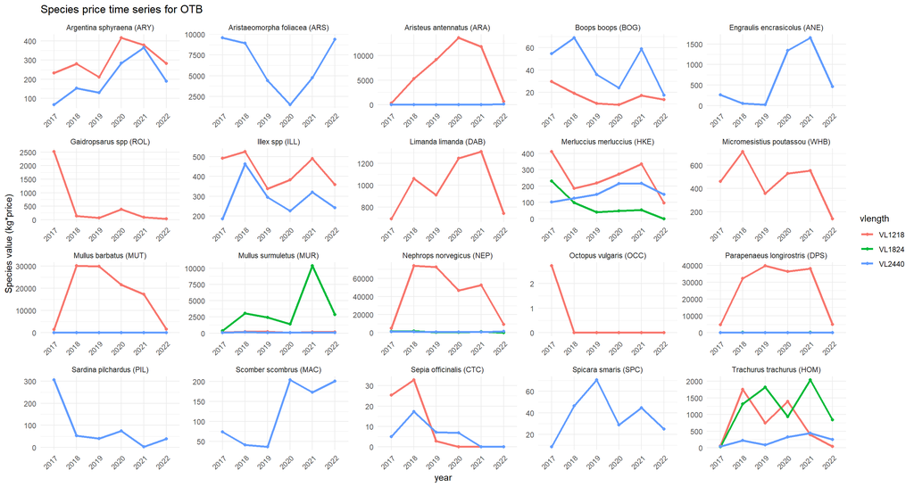

```r
FAO_sp = read.csv(paste0(wd,"ASFIS_sp_2025.csv")) %>% select("Alpha3_Code","Scientific_Name") %>% rename("species" = "Alpha3_Code")

FDI_land_spe_filter$year = as.character(FDI_land_spe_filter$year)

gear_filter = unique(FDI_land_spe_filter$gear)

for (g in seq_along(gear_filter)) {

  print(FDI_land_spe_filter %>%
    filter(gear == gear_filter[g]) %>%
  group_by(year, vlength, species) %>%
  summarise(m_yearly_value = mean(yearly_value)) %>%
  left_join(FAO_sp) %>%
  mutate(sp_id = paste0(Scientific_Name," (",species,")")) %>%

        ggplot(aes(x = year, y = m_yearly_value, color = vlength,
                   group = interaction(species, vlength)

                   )) +
        geom_line(size = 1.1) +
        geom_point() +
        facet_wrap(~ sp_id, scales = "free", ncol = 5) +
        theme_minimal() +
        ggtitle(paste0("Species price time series for ", gear_filter[g])) +
        ylab("Species value (kg*price) ")+
        theme(axis.text.x = element_text(angle = 45, vjust = 1, hjust = 1))
)
  }
```

```r
 species_price = FDI_land_spe_filter %>%
                    group_by(species, year) %>%
                    summarise(m_yearly_kg = mean(yearly_kg),
                              m_yearly_value = mean(yearly_value)) %>%
                    mutate(price = m_yearly_value/m_yearly_kg)
```

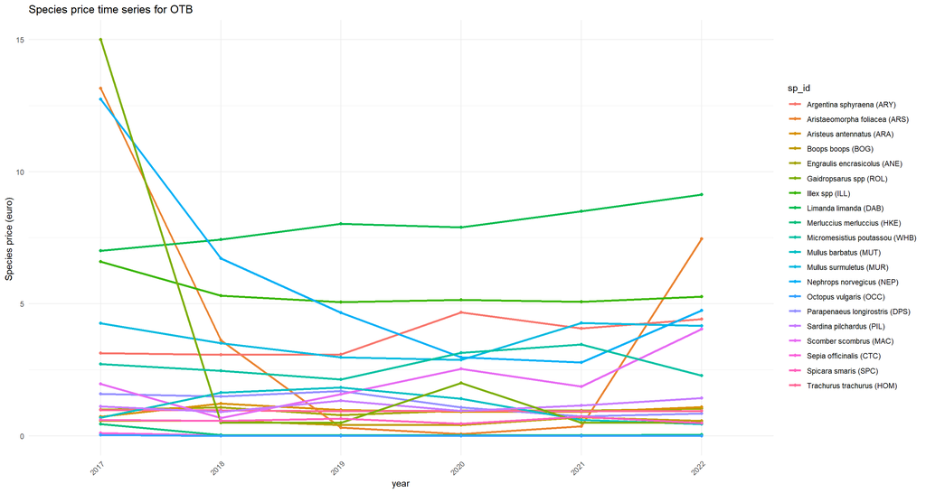

```r
  print(species_price %>%
  left_join(FAO_sp) %>%
  mutate(sp_id = paste0(Scientific_Name," (",species,")")) %>%

        ggplot(aes(x = year, y = price,
                   group = species, color = sp_id)) +
        geom_line(size = 1.1) +
        geom_point() +
        theme_minimal() +
        ggtitle(paste0("Species price time series for ", gear_filter[g])) +
        ylab("Species price (euro) ")+
        theme(axis.text.x = element_text(angle = 45, vjust = 1, hjust = 1))
)
```

```r
  FDI_land_spe_filter = left_join(FDI_land_spe_filter, species_price)
```

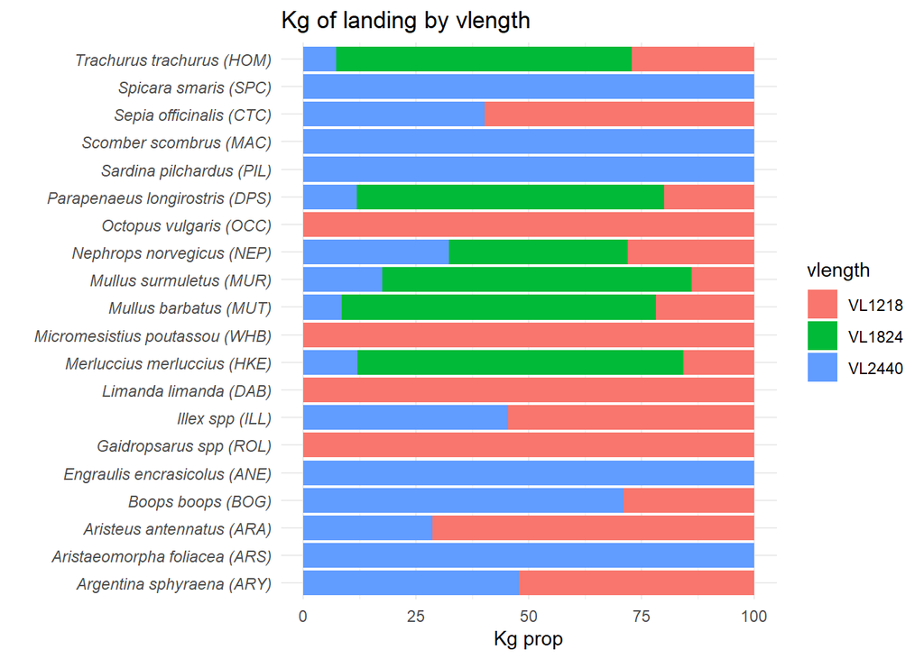

```r
for (g in seq_along(gear_filter)) {
print(
  FDI_land_spe_filter %>%
  filter(gear == gear_filter[g]) %>%
   group_by(vlength,species) %>%
   summarise(kg_gear = sum(yearly_kg)) %>%
  group_by(species) %>%
  mutate(kg_tot = sum(kg_gear)) %>%
  mutate(kg_prop = (kg_gear/kg_tot)*100) %>%
  left_join(FAO_sp) %>%
  mutate(sp_id = paste0(Scientific_Name," (",species,")")) %>%
  ggplot() +
  geom_bar(aes(y = sp_id, x = kg_prop, fill = vlength),stat = "identity") +
  labs(title = "Kg of landing by vlength", y = "", x = "Kg prop") +
  theme_minimal()+
  theme(axis.text.y = element_text(face = "italic")))
}
```

Save data filtered

```r
 saveRDS(FDI_land_spe_filter, paste0(fd_price,"FDI_land_spe_filter.RData"))
```

### Step 3 - Calculate and add price by species

The previously calculated weights were then joined with the species price resulting dataset, allowing landings to be distributed across ports. Following this process, the weighted price by species were calculated.

```r
nvessel_port =  read_sf(paste0(fd,"output_df_2021.shp")) %>%
                st_drop_geometry() %>%
                select(MMSI, vlength, port, Gear) %>%
                mutate(year = "2021") %>%
                unique()
```

```r
nvessel_port <- nvessel_port %>%
                group_by(year, Gear, vlength, port) %>%
                summarise(n_vessel_port = n())
nvessel_weighted <- nvessel_port %>%
                     group_by(year, Gear, vlength) %>%
                     mutate(sum_nvessel = sum(n_vessel_port),
                       weight = n_vessel_port / sum_nvessel) %>%
                     rename(gear = Gear)

FDI_land_spe_filter = readRDS(paste0(fd_price,"FDI_land_spe_filter.RData"))

FDI_land_spe_nvessel <- FDI_land_spe_filter %>%
                         inner_join(nvessel_weighted, by = c("year", "gear", "vlength"))
FDI_land_spe_nvessel <- FDI_land_spe_nvessel %>%
                         group_by(year, vlength, gear, species,port) %>%
                          summarise(
                            mval_by_port = yearly_value * weight,
                            mkg_by_port = yearly_kg * weight)
```

[output not shown]

```r
final_effort = read_sf(paste0(fd, "output_df_2021.shp")) %>%
                rename(gear = Gear)



final_FDI_nvessel_port = FDI_land_spe_nvessel

coords_port = final_effort[c("port", "lon_port","lat_port")] %>% st_drop_geometry() %>% unique()

spe_mval_port = final_FDI_nvessel_port %>%
                group_by(species, vlength, gear, port) %>%
                summarise(mval_mean = mean(mval_by_port),mkg_mean = mean(mkg_by_port))  %>%
                left_join(coords_port) %>%
                st_as_sf(coords = c("lon_port","lat_port"), crs = st_crs(final_effort))
final_effort_cell = final_effort %>%
  group_by(cscode, vlength) %>%
  summarise(fishing_hours = mean(GFW_hours, na.rm = T))
```

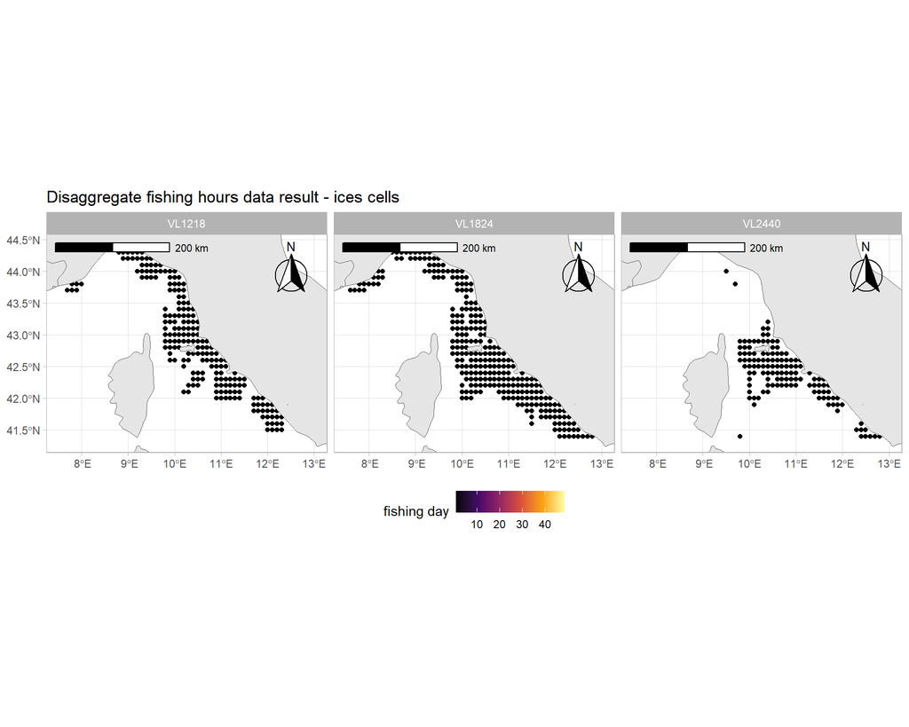

```r
final_effort_cell %>%
  ggplot +
  geom_sf(aes(fill = fishing_hours))+
  facet_wrap(~ vlength)+
  geom_sf(data = world)+
  scale_fill_viridis_c("fishing day",option = "inferno",  na.value = "white")+
  coord_sf(xlim = c(xmin, xmax), ylim = c(ymin, ymax))+
  annotation_scale(location = "tl", width_hint = 0.5) +
  annotation_north_arrow(location = "tr", which_north = "true",
                         pad_x = unit(0.1, "in"), pad_y = unit(0.1, "in"),
                         style = north_arrow_fancy_orienteering) +
  ggtitle(paste0("Disaggregate fishing hours data result - ices cells"))+
  theme_light()+
  theme(legend.position = "bottom")
```

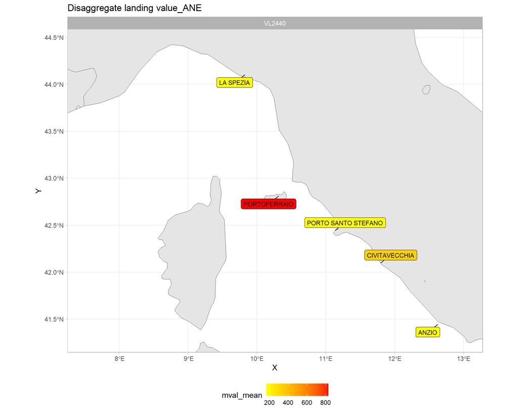

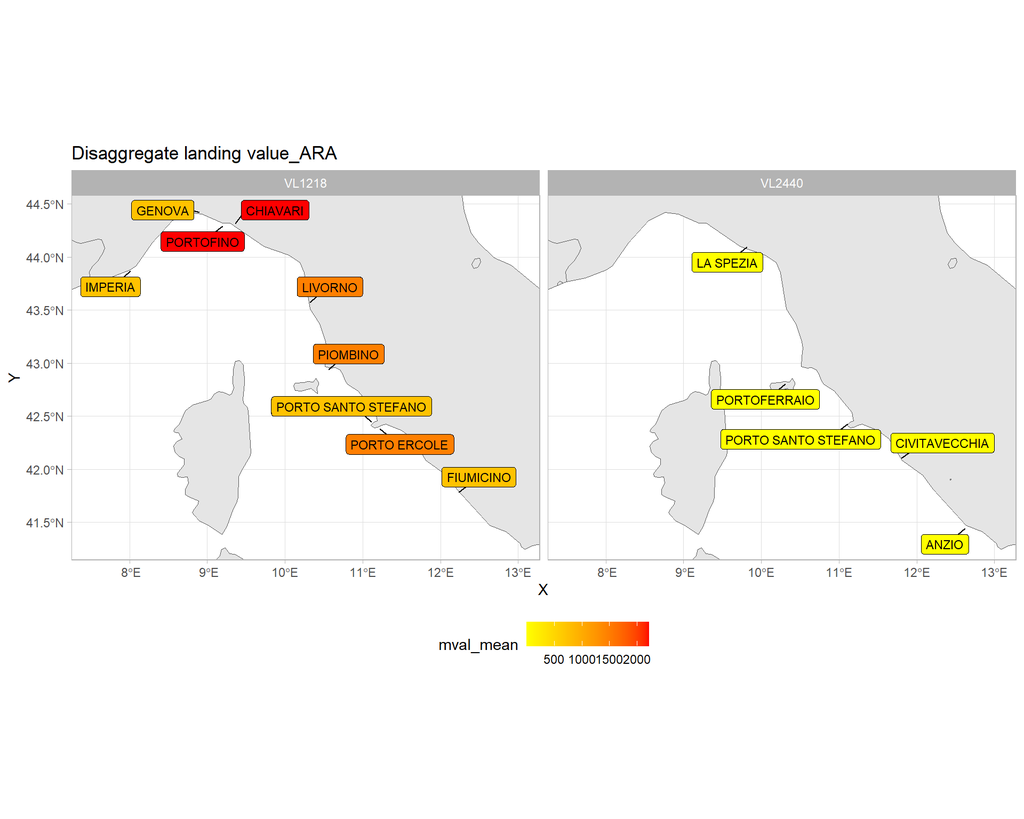

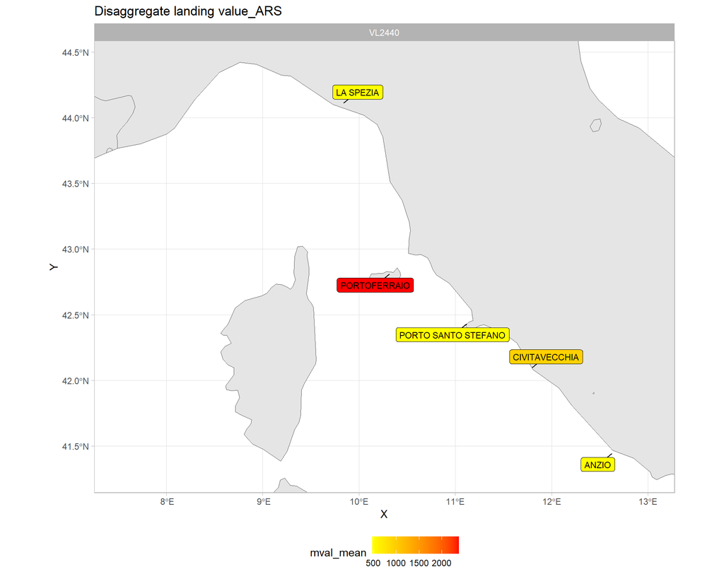

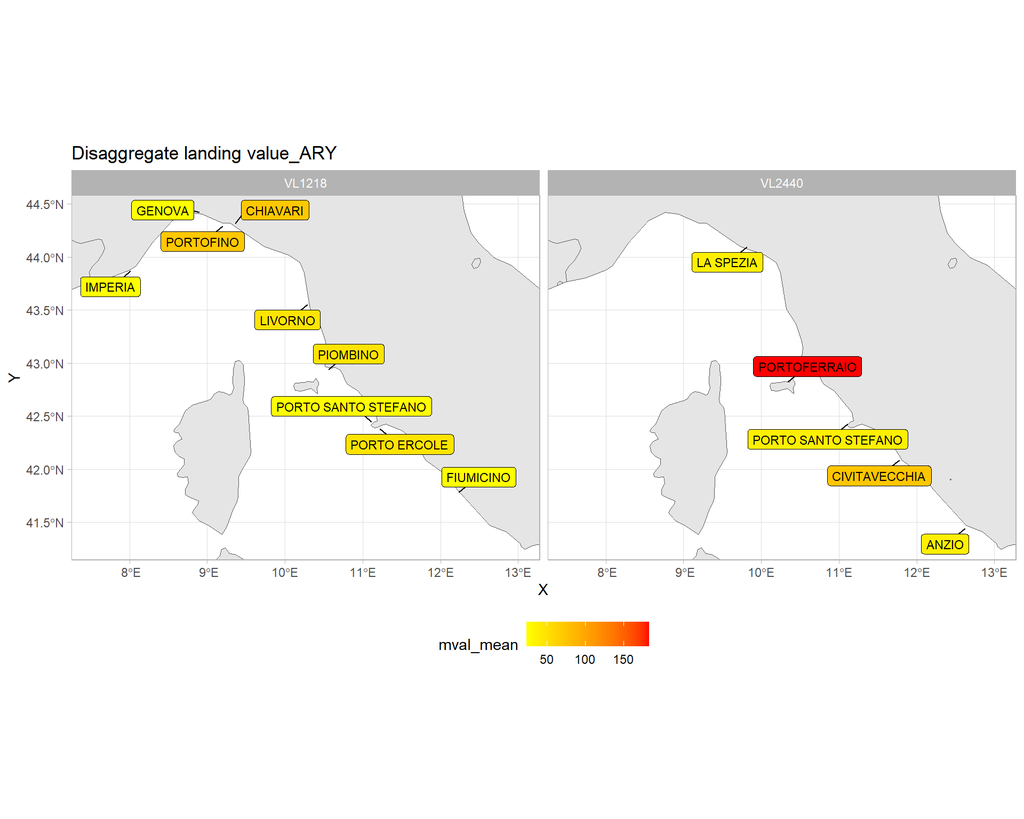

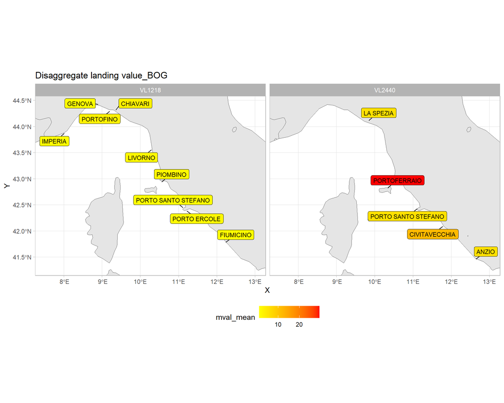

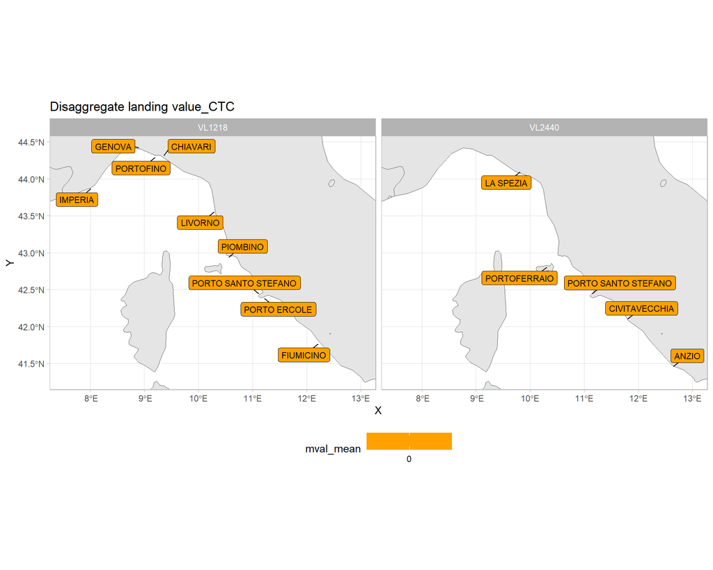

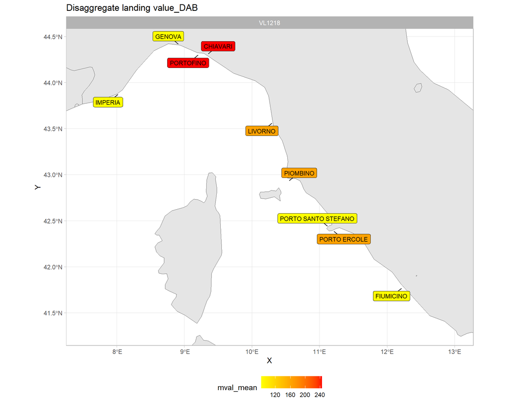

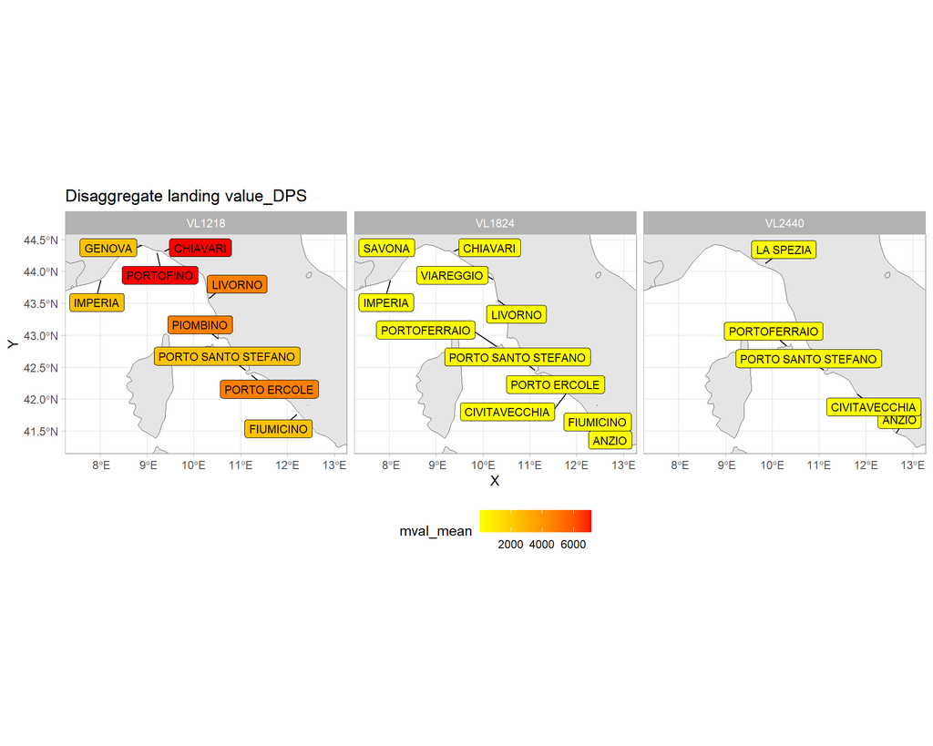

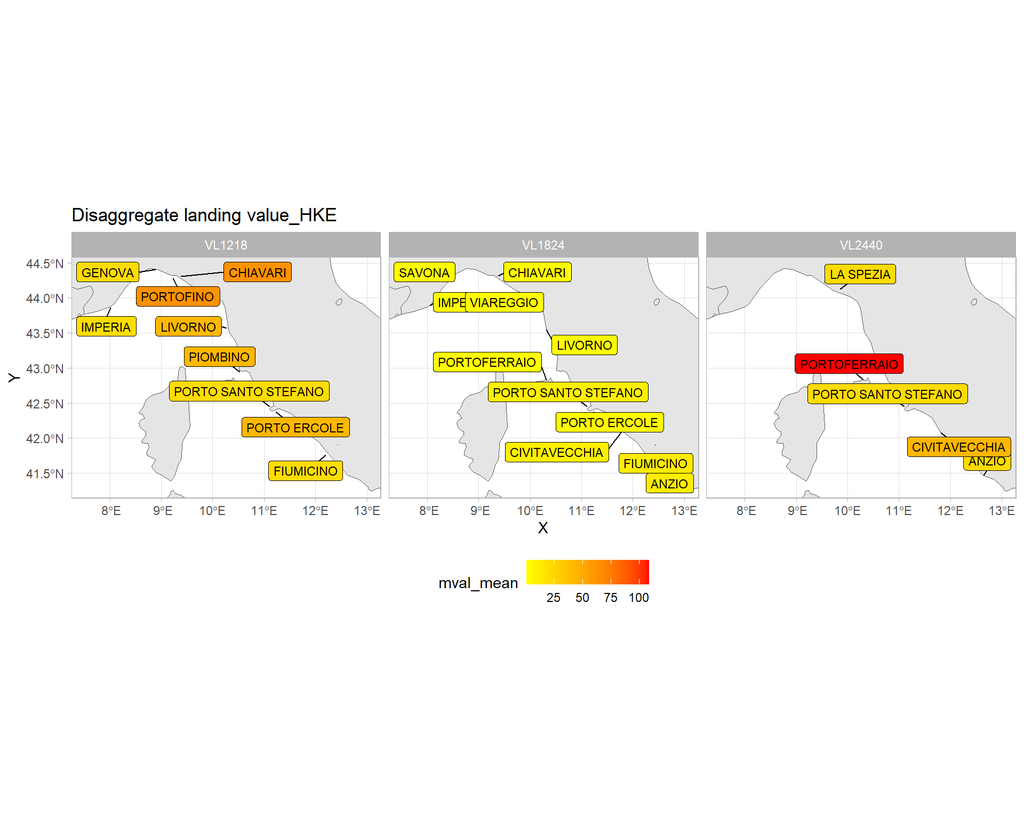

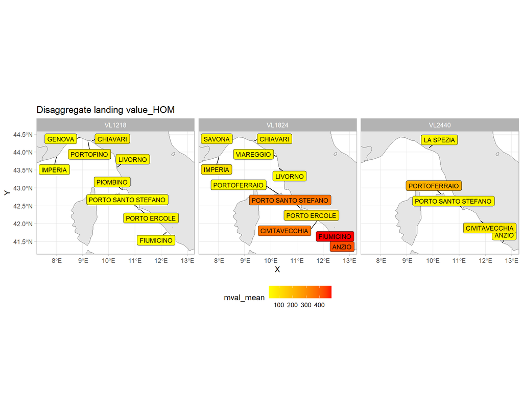

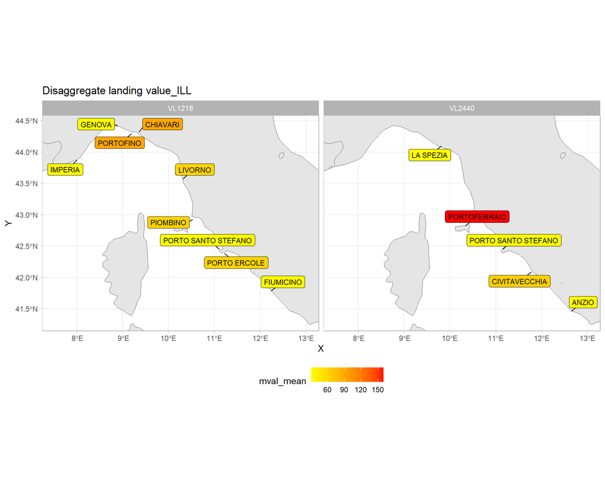

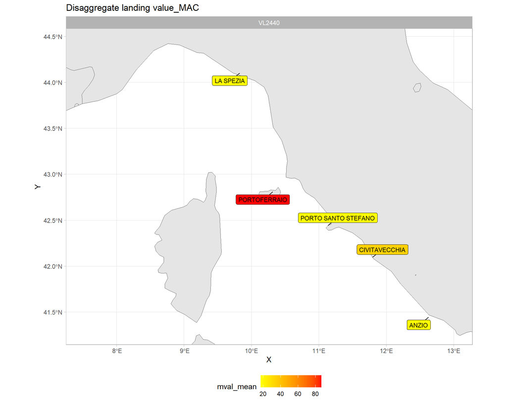

[8 more figures not shown]

```r
spe = unique(spe_mval_port$species)

coords_port = spe_mval_port %>%
  select(port, species, mval_mean, vlength) %>%  # keep geometry
  unique() %>%
  rowwise() %>%
  mutate(
    X = st_coordinates(geometry)[1, 1],
    Y = st_coordinates(geometry)[1, 2]
  ) %>%
  ungroup() %>%
  st_drop_geometry()


for(i in 1:length(spe)){
print(coords_port %>%
  filter(species %in% spe[i]) %>%
  ggplot()+
   geom_sf(data = world)+
 geom_label_repel(
      aes(x = X, y = Y, label = port, fill = mval_mean),
      size = 3,
      min.segment.length = 0)+
     scale_fill_gradient(low = "yellow", high = "red", na.value = NA)+
    facet_wrap(~ vlength)+
  # geom_sf(data = final_effort_cell, aes(fill = fishing_day ))+
  # scale_fill_viridis_c(option = "D") +
  coord_sf(xlim = c(xmin, xmax), ylim = c(ymin, ymax))+
  ggtitle(paste0("Disaggregate landing value_", spe[i]))+
  theme_light()+
  theme(legend.position = "bottom"))
}
```

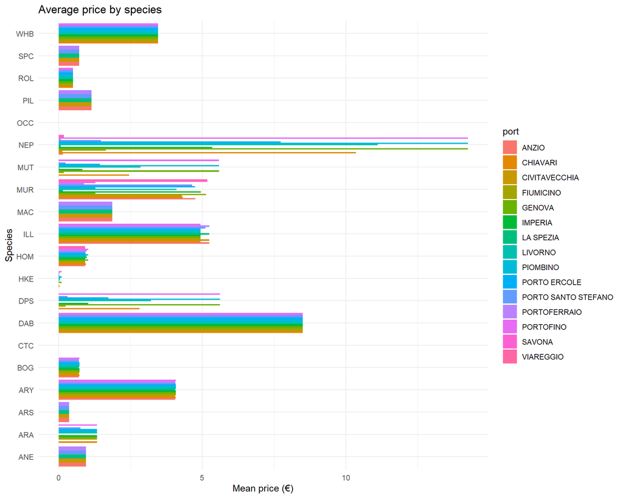

```r
final_FDI_nvessel_port %>%
  group_by(species, port) %>%
  summarise(mean_val_by_port = mean(mval_by_port ),
            mean_kg_by_port = mean(mkg_by_port),
    mean_price = mean_val_by_port/mean_kg_by_port) %>%

ggplot( aes(y = species, x = mean_price, fill = port)) +
  geom_bar(stat = "identity", position = "dodge") +
  theme_minimal() +
  scale_y_reordered() +
  labs(title = "Average price by species", x = "Mean price (€)", y = "Species")
```

```r
vessel_by_cell = final_effort %>% select(MMSI, cscode,gear, vlength) %>% st_drop_geometry() %>% unique()
effort_by_cell =  final_effort_cell %>% st_drop_geometry()
spe_by_port = spe_mval_port %>% st_drop_geometry()
vessel_by_port = final_effort %>% select(MMSI, vlength, port) %>% st_drop_geometry() %>% unique()
coords_port =  spe_mval_port %>%
                select(port) %>%
                unique() %>%
                mutate(
                  X = st_coordinates(.)[,1],
                  Y = st_coordinates(.)[,2]
                ) %>%
                st_drop_geometry()

coords_cell = final_effort %>%
                select(cscode) %>%
                unique()

write.csv(vessel_by_cell,"C:/Users/alice/OneDrive - CNR/Documenti - ABM-Fisheries-grp/General/Paper_blueconomy/Data/vessel_by_cell.csv",row.names = F)

write.csv(effort_by_cell,"C:/Users/alice/OneDrive - CNR/Documenti - ABM-Fisheries-grp/General/Paper_blueconomy/Data/effort_by_cell.csv",row.names = F)

write.csv(spe_by_port,"C:/Users/alice/OneDrive - CNR/Documenti - ABM-Fisheries-grp/General/Paper_blueconomy/Data/spe_by_port.csv",row.names = F)

write.csv(vessel_by_port,"C:/Users/alice/OneDrive - CNR/Documenti - ABM-Fisheries-grp/General/Paper_blueconomy/Data/vessel_by_port.csv",row.names = F)

write.csv(coords_port,"C:/Users/alice/OneDrive - CNR/Documenti - ABM-Fisheries-grp/General/Paper_blueconomy/Data/coords_port.csv",row.names = F)

write_sf(coords_cell,"C:/Users/alice/OneDrive - CNR/Documenti - ABM-Fisheries-grp/General/Paper_blueconomy/Data/coords_cell.shp",row.names = F)
```

## Conclusion

Overall, the disaggregation protocol developed under WP2 provides a replicable and adaptable framework to enhance the spatial granularity and analytical potential of fisheries socio-economic data. While subject to certain limitations—chiefly related to data availability and resolution, the approach demonstrates the feasibility of integrating heterogeneous data sources (FDI, AER, GFW, and fleet register) to derive vessel-level and port-level indicators. This not only improves the precision of fisheries monitoring and assessment but also strengthens the foundational data layer required for advanced socio-ecological modeling within the Digital Twin of the Ocean. Future work will focus on validating this methodology across multiple regions and fleet segments, with the goal of operating it within broader simulation workflows and policy support tools.